# Εφαρμοσμένη Επιστήμη Δεδομένων 2026

## Προγραμματιστική Εργασία: Βιοποικιλότητα Πουλιών στην Ελλάδα

**Όνομα:** Στέλλα Μουμτζή **Αριθμός Μητρώου (ΑΜ):** 3220127  
**Ημερομηνία Υποβολής:** 20/04/2026

### Οδηγίες

- Αντικαταστήστε κάθε `# TODO` με τον κώδικά σας.
- Χρησιμοποιήστε κελιά **markdown** για τα σχόλια και τα συμπεράσματά σας (όπου ζητείται).
- Πριν υποβάλετε: **Kernel → Restart & Run All** για να επαληθεύσετε ότι τρέχει χωρίς σφάλματα.
- Αποθηκεύστε ως `coding_exercise_ads_2026_<ΑΜ>.ipynb`.

### Χρήση AI/LLM

Η χρήση εργαλείων τεχνητής νοημοσύνης επιτρέπεται και ενθαρρύνεται. Μαζί με την εργασία υποβάλετε υποχρεωτικά το αρχείο `coding_exercise_ads_2026_prompts_<ΑΜ>.md` — χρησιμοποιήστε το `coding_exercise_ads_2026_template_prompts.md` ως πρότυπο. Βλ. αναλυτικές οδηγίες στην εκφώνηση.

```python
import calendar
import time
import warnings
from io import BytesIO
from pathlib import Path

import matplotlib.pyplot as plt
import numpy as np
import pandas as pd
import requests
import seaborn as sns
import folium
from folium.plugins import HeatMap
from PIL import Image as PILImage
from tqdm import tqdm

warnings.filterwarnings('ignore')
%matplotlib inline
sns.set_theme(style='whitegrid')

MONTH_LABELS = [calendar.month_abbr[i] for i in range(1, 13)]
print('Βιβλιοθήκες φορτώθηκαν επιτυχώς.')
```

```
Βιβλιοθήκες φορτώθηκαν επιτυχώς.
```

## Φόρτωση Δεδομένων

Τα δεδομένα φορτώνονται από το αρχείο `birds_greece.csv`.  
Αν δεν βρεθεί αρχείο, κατεβαίνουν αυτόματα από το **GBIF API**.

```python
RECORDS_PER_MONTH = 100 # Λίγα από κάθε μήνα για να καλυφθεί όλο το έτος

_LOCAL = Path(f'birds_greece_100per_month.csv')

if _LOCAL.exists():
    df_raw = pd.read_csv(_LOCAL)
    print(f'Φορτώθηκε από τοπικό αρχείο: {len(df_raw):,} εγγραφές ({_LOCAL})')
else:
    print('CSV δεν βρέθηκε — κατέβασμα από GBIF API...')
    BASE_URL = 'https://api.gbif.org/v1/occurrence/search'
    records = []

    for yr in tqdm(range(2001, 2026), desc='Έτη'):
        for month in range(1, 13):
                params = [
                    ('taxonKey', 212), ('country', 'GR'),
                    ('hasCoordinate', 'true'), ('year', yr),
                    ('month', month),
                    ('limit', RECORDS_PER_MONTH)
                ]
                try:
                    r = requests.get(BASE_URL, params=params, timeout=45)
                    r.raise_for_status()
                    data = r.json()
                    results = data.get('results', [])
                    # Σε περίπτωση που επιστραφούν περισσότερες
                    results = results[:RECORDS_PER_MONTH]

                    if not results:
                        break

                    # Φιλτράρισμα και επιλογή μόνο των απαραίτητων πεδίων
                    for rec in results:
                        records.append({
                            'species': rec.get('species'),
                            'eventDate': rec.get('eventDate'),
                            'year': rec.get('year'),
                            'month': rec.get('month'),
                            'decimalLatitude': rec.get('decimalLatitude'),
                            'decimalLongitude': rec.get('decimalLongitude'),
                            'datasetName': rec.get('datasetName'),
                            'occurrenceID': rec.get('key'),
                            'license': rec.get('license'),
                            'vernacularName': rec.get('vernacularName')
                        })

                    if data.get('endOfRecords', True):
                        break
                except Exception as e:
                    print(f'  Σφάλμα {month}/{yr}: {e}')
                    continue # Προχωράμε στον επόμενο μήνα

    df_raw = pd.DataFrame(records)
    df_raw.to_csv(_LOCAL, index=False)
    print(f'API: {len(df_raw):,} εγγραφές (αποθηκεύτηκε στο {_LOCAL})')

has_image = df_raw['image_url'].notna().sum() if 'image_url' in df_raw.columns else 0
print(f'\nΣύνολο εγγραφών: {len(df_raw):,} | Με εικόνα: {has_image:,}')
df_raw.head()
```

```
Φορτώθηκε από τοπικό αρχείο: 26,886 εγγραφές (birds_greece_100per_month.csv)

Σύνολο εγγραφών: 26,886 | Με εικόνα: 0
```

|  | species | eventDate | year | month | decimalLatitude | decimalLongitude | datasetName | occurrenceID | license | vernacularName |
| --- | --- | --- | --- | --- | --- | --- | --- | --- | --- | --- |
| 0 | Turdus philomelos | 2001-01-10 | 2001 | 1 | 40.546400 | 23.017500 | NaN | 2720125867 | http://creativecommons.org/licenses/by/4.0/leg... | Song Thrush |
| 1 | Vanellus vanellus | 2001-01-07 | 2001 | 1 | 40.672394 | 23.134317 | NaN | 2721811807 | http://creativecommons.org/licenses/by/4.0/leg... | Northern Lapwing |
| 2 | Anas platyrhynchos | 2001-01-01 | 2001 | 1 | 41.229492 | 23.107971 | NaN | 2754647519 | http://creativecommons.org/licenses/by/4.0/leg... | Mallard |
| 3 | Phalacrocorax carbo | 2001-01-01 | 2001 | 1 | 41.229492 | 23.107971 | NaN | 2758290685 | http://creativecommons.org/licenses/by/4.0/leg... | Great Cormorant |
| 4 | Tachybaptus ruficollis | 2001-01-01 | 2001 | 1 | 41.229492 | 23.107971 | NaN | 2759617365 | http://creativecommons.org/licenses/by/4.0/leg... | Little Grebe |

**Σχόλιο για τη φόρτωση των δεδομένων:**

Για να μειωθεί ο χρόνος εκτέλεσης αλλά και το μέγεθος του αρχείου birds_greece_100_per_year.csv έχω ακολουθήσει μια διαφορετική προσέγγιση, για αυτό και έχουν γίνει κάποιες αλλαγές στον κώδικα. Συγκεκριμένα, έχω επιλέξει να φορτώνω τα δεδομένα ανα μήνα έτσι ώστε να μην υπάρχουν μήνες για τους οποίους δεν υπάρχουν δεδομένα. Επέλεξα να κρατάω τις 100 πρώτες εγγραφές απο κάθε μήνα έτσι ώστε το σύνολο εγγραφών να είναι βολικό(τώρα στις 26.886 εγγραφές) αλλά και αρκετό για τις μετρήσεις αργότερα. Επίσης, για λόγους βελτιστοποίησης του χρόνου, έχω επιλέξει να φορτώνω μόνο τις στήλες που χρειάζονται για την εργασία.

```
Είδος: Chloris chloris
Έτος:  2025
URL:   https://inaturalist-open-data.s3.amazonaws.com/photos/461950615/original.jpeg
```

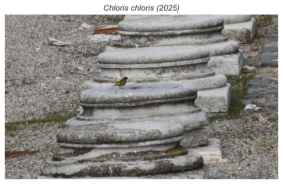

```python
# Παράδειγμα εγγραφής με εικόνα για το 2025
search_url = "https://api.gbif.org/v1/occurrence/search"
params = {
    "taxonKey": 212,
    "country": "GR",
    "year": 2025,
    "mediaType": "StillImage",
    "limit": 1
}

r = requests.get(search_url, params=params)
data = r.json()

if data['results'] and 'media' in data['results'][0]:
    sample = data['results'][0]
    media = sample.get('media', [])
    sample['image_url'] = media[0]['identifier'] if media and 'identifier' in media[0] else None
    print(f"Είδος: {sample.get('species', 'N/A')}")
    print(f"Έτος:  {int(sample['year'])}")
    print(f"URL:   {sample['image_url']}")

    resp = requests.get(sample['image_url'], timeout=15)
    img = PILImage.open(BytesIO(resp.content))

    fig, ax = plt.subplots(figsize=(6, 4))
    ax.imshow(img)
    ax.set_title(f"{sample.get('species', '')} ({int(sample['year'])})", fontsize=12, style='italic')
    ax.axis('off')
    plt.tight_layout()
    plt.show()
else:
    print("Δεν βρέθηκε ακόμα εγγραφή με εικόνα για το 2025")
```

**Σχόλιο για την εμφάνιση εγγραφής με εικόνα:**

Λόγω του τρόπου που φορτώθηκαν τα δεδομένα στο αρχείο csv, αυτό δεν περιέχει εικόνες. Για αυτόν τον λόγο γίνεται αναζήτηση μέσω του GBIF API.

## Μέρος Α — Εξερεύνηση Δεδομένων

### Α1. Φόρτωση & Επισκόπηση *(10 μονάδες)*

```python
new_df = df_raw.copy()

new_df['eventDate'] = pd.to_datetime(new_df['eventDate'], errors='coerce')

print(f"Διαστάσεις DataFrame: {new_df.shape}")

print(f"\nΤύποι στηλών: \n{new_df.dtypes}")

print(f"\nΑριθμός μοναδικών ειδών: {new_df['species'].nunique()}")

print(f"\nΕλάχιστο έτος: {new_df['year'].min()} | Μέγιστο έτος: {new_df['year'].max()}")
print(f"Χρονικό εύρος: {new_df['eventDate'].min()} - {new_df['eventDate'].max()}\n")

for col in new_df.columns:
    null_count = new_df[col].isnull().sum()
    print(f"Στήλη '{col}': {null_count} null τιμές")

new_df.dropna(subset=['species'], inplace=True)
print(f"\nΑριθμός εγγραφών μετά την αφαίρεση null τιμών: {len(new_df)}")
```

```
Διαστάσεις DataFrame: (26886, 10)

Τύποι στηλών:
species                     object
eventDate           datetime64[ns]
year                         int64
month                        int64
decimalLatitude            float64
decimalLongitude           float64
datasetName                 object
occurrenceID                 int64
license                     object
vernacularName              object
dtype: object

Αριθμός μοναδικών ειδών: 354

Ελάχιστο έτος: 2001 | Μέγιστο έτος: 2025
Χρονικό εύρος: 2001-01-01 00:00:00 - 2025-12-05 00:00:00

Στήλη 'species': 371 null τιμές
Στήλη 'eventDate': 10218 null τιμές
Στήλη 'year': 0 null τιμές
Στήλη 'month': 0 null τιμές
Στήλη 'decimalLatitude': 0 null τιμές
Στήλη 'decimalLongitude': 0 null τιμές
Στήλη 'datasetName': 16688 null τιμές
Στήλη 'occurrenceID': 0 null τιμές
Στήλη 'license': 0 null τιμές
Στήλη 'vernacularName': 10533 null τιμές

Αριθμός εγγραφών μετά την αφαίρεση null τιμών: 26515
```

**Σχόλιο για ελλιπείς τιμές (Α1):**

- Γιατί οι στήλες `decimalLatitude`/`decimalLongitude` δεν έχουν null τιμές;

  Λόγω της παραμέτρου ('hasCoordinate', 'true') κατά τη φόρτωση δεδομένων.
- Γιατί η στήλη `vernacularName` έχει πολλά nulls;

  Γιατί για τα περισσότερα είδη δεν υπάρχει κοινή ονομασία και έτσι το πεδίο μένει κενό.
- Πόσες εγγραφές αφαιρέθηκαν και γιατί;

  Αφαιρέθηκαν 371(26886-26515) εγγραφές διότι τόσες είναι με null στη στήλη species.

### Α2. Βασική Στατιστική *(20 μονάδες)*

#### Α2.i — Σύνοψη *(5 μονάδες)*

```python
base_url = "https://api.gbif.org/v1/occurrence/search"
rec_gr = requests.get(base_url, params={'taxonKey': 212, 'country': 'GR', 'limit': 0})
total_gr = rec_gr.json().get('count', 0)
rec_global = requests.get(base_url, params={'taxonKey': 212, 'limit': 0})
total_global = rec_global.json().get('count', 0)

print(f"Εγγραφές στο δείγμα: {len(new_df):,}")
print(f"\nΣύνολο εγγραφών στην Ελλάδα: {total_gr:,}")
print(f"\nΣύνολο εγγραφών παγκοσμίως: {total_global:,}")
print(f"\nΠοσοστό ελληνικού δείγματος: {len(new_df)/total_gr:.3%}")
print(f"\nΠοσοστό παγκόσμιου δείγματος: {len(new_df)/total_global:.3%}")

print(f"\nΚατανομή ανά άδεια χρήσης: {new_df['license'].value_counts()}")

print(f"\nΑριθμός μοναδικών ειδών: {new_df['species'].nunique()}")
print(f"\nΑριθμός μοναδικών πηγών δεδομένων: {new_df['datasetName'].nunique()}")
print(f"\nΣύνολο εγγραφών ανά πηγή δεδομένων:\n{new_df['datasetName'].value_counts()}")
```

```
Εγγραφές στο δείγμα: 26,515

Σύνολο εγγραφών στην Ελλάδα: 2,580,105

Σύνολο εγγραφών παγκοσμίως: 2,333,133,489

Ποσοστό ελληνικού δείγματος: 1.028%

Ποσοστό παγκόσμιου δείγματος: 0.001%

Κατανομή ανά άδεια χρήσης: license
http://creativecommons.org/licenses/by/4.0/legalcode          18179
http://creativecommons.org/licenses/by-nc/4.0/legalcode        7769
http://creativecommons.org/publicdomain/zero/1.0/legalcode      567
Name: count, dtype: int64

Αριθμός μοναδικών ειδών: 354

Αριθμός μοναδικών πηγών δεδομένων: 5

Σύνολο εγγραφών ανά πηγή δεδομένων:
datasetName
iNaturalist research-grade observations                                                                  9487
Birdmap data                                                                                              584
Bird ringing and recovery database (TIPU)                                                                  21
Global Roadkill Data: a dataset on terrestrial vertebrate mortality caused by collision with vehicles       1
Minu loodusheli                                                                                             1
Name: count, dtype: int64
```

**Σχόλιο για τις άδειες χρήσης:**

Όπως φαίνεται έχει γίνει χρήση των αδειών **CC BY 4.0**, **CC BY-NC 4.0** αλλά και της **CC0 1.0**.

#### Α2.ii — Top-10 Είδη *(8 μονάδες)*

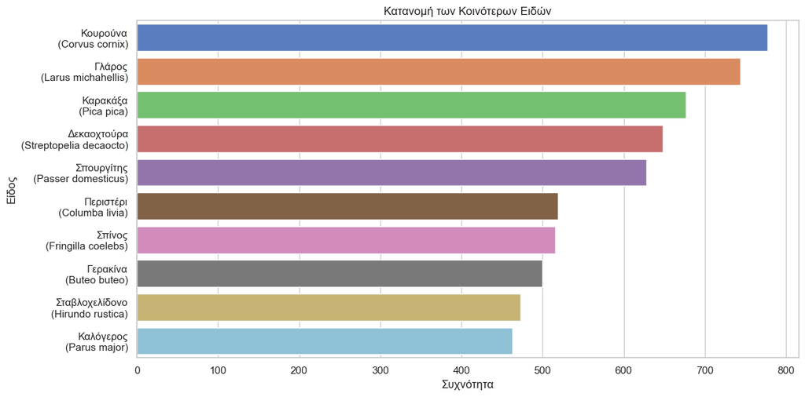

```
Τα top-10 είδη αντιπροσωπεύουν το 22.42% του συνόλου των εγγραφών.
```

```python
# Λεξικό κοινών ονομάτων (επιστημονικό → ελληνικό κοινό)
GREEK_NAMES = {
    'Phoenicopterus roseus':      'Φλαμίνγκο',
    'Larus michahellis':          'Γλάρος',
    'Egretta garzetta':           'Λευκοτσικνιάς',
    'Tadorna tadorna':            'Βαρβάρα',
    'Microcarbo pygmaeus':        'Νανοκορμοράνος',
    'Phalacrocorax carbo':        'Κορμοράνος',
    'Ardea cinerea':              'Ερωδιός',
    'Corvus cornix':              'Κουρούνα',
    'Chroicocephalus ridibundus': 'Αλογάκι',
    'Passer domesticus':          'Σπουργίτης',
    'Himantopus himantopus':      'Καλαμοκανάς',
    'Ciconia ciconia':            'Πελαργός',
    'Ciconia nigra':              'Μαύρος Πελαργός',
    'Fulica atra':                'Φαλαρίδα',
    'Anas platyrhynchos':         'Πρασινοκέφαλος',
    'Pelecanus crispus':          'Πελεκάνος',
    'Nycticorax nycticorax':      'Νυχτοκόρακας',
    'Recurvirostra avosetta':     'Αβοκέτα',
    'Podiceps cristatus':         'Βουτηχτάρι',
    'Pica pica':                  'Καρακάξα',
    'Streptopelia decaocto':      'Δεκαοχτούρα',
    'Columba livia':              'Περιστέρι',
    'Fringilla coelebs':          'Σπίνος',
    'Buteo buteo':                'Γερακίνα',
    'Hirundo rustica':            'Σταβλοχελίδονο',
    'Parus major':                'Καλόγερος'
}

def species_label(sci_name):
    """Επιστρέφει ετικέτα με ελληνικό + επιστημονικό όνομα."""
    greek = GREEK_NAMES.get(sci_name, '')
    return f'{greek}\n({sci_name})' if greek else sci_name

most_common_species = new_df['species'].value_counts().head(10)

df = pd.DataFrame(
    {
    'Είδος': most_common_species.index.map(species_label),
    'Συχνότητα': most_common_species.values
    }
)
plt.figure(figsize=(12, 6))
sns.barplot(
    x='Συχνότητα',
    y='Είδος',
    data=df,
    palette='muted'
)

plt.title("Κατανομή των Κοινότερων Ειδών")
plt.xlabel('Συχνότητα')
plt.ylabel('Είδος')
plt.tight_layout()

# Show plot
plt.show()

total_count = new_df['species'].count()
top_10_count = most_common_species.sum()
percentage = (top_10_count / total_count) * 100
print(f"\nΤα top-10 είδη αντιπροσωπεύουν το {percentage:.2f}% του συνόλου των εγγραφών.")
```

```python
def get_wiki_image(species_name, retries=3, delay=1.5):
    """Κατεβάζει την κύρια εικόνα Wikipedia για ένα είδος."""
    slug = species_name.replace(' ', '_')
    headers = {'User-Agent': 'ADS2026-birdproject/1.0'}
    try:
        summary = requests.get(
            f'https://en.wikipedia.org/api/rest_v1/page/summary/{slug}',
            timeout=10, headers=headers
        ).json()
        thumb = summary.get('thumbnail') or {}
        orig  = summary.get('originalimage') or {}
        img_url = thumb.get('source') or orig.get('source', '')
        if not img_url or img_url.lower().endswith('.svg'):
            return None
        for attempt in range(retries):
            resp = requests.get(img_url, timeout=15, headers=headers)
            if resp.status_code == 429:
                time.sleep(delay * (attempt + 1))
                continue
            resp.raise_for_status()
            return PILImage.open(BytesIO(resp.content)).convert('RGB')
    except Exception as exc:
        print(f'  Δεν βρέθηκε εικόνα για {species_name}: {exc}')
    return None
```

#### Α2.iii — Κατανομή Συχνότητας Καταγραφής *(3 μονάδες)*

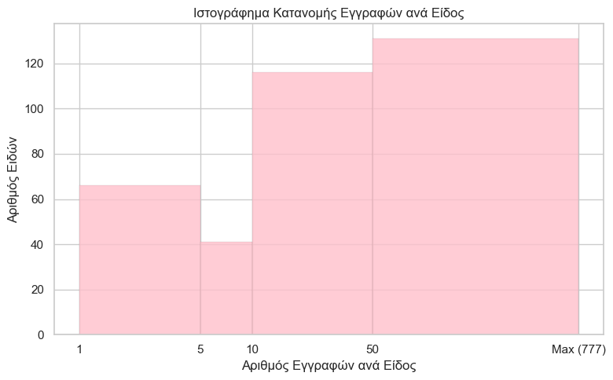

```
Αριθμός ειδών με 2 ή λιγότερες εγγραφές: 11.86%
```

```python
species_counts = new_df['species'].value_counts()

max_val = species_counts.max() # Για να ορίσουμε το άνω όριο των bins στο μέγιστο πλήθος εγγραφών
bins = [0, 1, 5, 10, 50, max_val]
plt.figure(figsize=(8, 5))

# Plot a histogram
ax = sns.histplot(species_counts, bins=bins, color='pink', alpha=0.8, edgecolor='black')
plt.xscale('log') # Λογαριθμική κλίμακα στον άξονα Χ
plt.xticks([1, 5, 10, 50, max_val], ['1', '5', '10', '50', f'Max ({max_val})'])
plt.title('Ιστογράφημα Κατανομής Εγγραφών ανά Είδος')
plt.xlabel('Αριθμός Εγγραφών ανά Είδος')
plt.ylabel('Αριθμός Ειδών')
plt.tight_layout()
plt.show()

rare_species_count = (species_counts <= 2).sum()
print(f"\nΑριθμός ειδών με 2 ή λιγότερες εγγραφές: {rare_species_count/species_counts.count():.2%}")
```

**Σχόλιο για κατανομή καταγραφών (Α2.iii):**

- Τι σχήμα έχει η κατανομή (long-tail, κανονική, κ.ά.);

  Απο το long-tail σχήμα της κατανομής, με μια εξαίρεση στο διάστημα '5-10', φαίνεται οτι τα περισσότερα είδη έχουν πολλές καταγραφές.
- Τι λέει το ποσοστό «σπάνιων» ειδών (≤2 παρατηρήσεις) για την **προσπάθεια καταγραφής** στο σύνολο δεδομένων;

  Το ποσοστό είναι χαμήλο και αποκαλύπτει μια συνεχή προσπάθεια καταγραφής. Αντιθέτως, αν το ποσοστό ήταν μεγάλο θα σήμαινε πως δεν έχουν γίνει πολλές παρατηρήσεις και υπάρχουν πολλά είδη απο λίγες καταγραφές το καθένα. Αυτή η παρατήρηση επιβεβαιώνει και το σχήμα της κατανομής και φανερώνει πάλι την ύπαρξη πολλών καταγραφών για τα περισσότερα είδη.

## Μέρος Β — Χρονική & Εποχιακή Ανάλυση

### Β1. Ετήσια Τάση *(15 μονάδες)*

#### Β1.i — Παρατηρήσεις ανά Έτος *(5 μονάδες)*

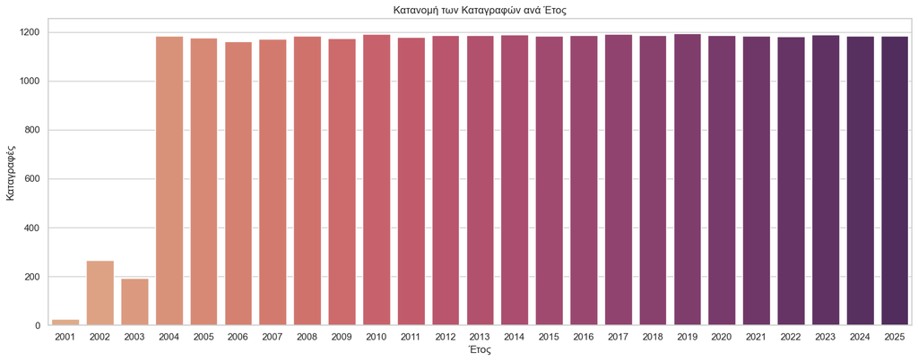

```python
records_per_year = new_df['year'].value_counts().sort_index()
df = pd.DataFrame(
    {
    'Record Count': records_per_year.values,
    'Year': records_per_year.index
    }
)
plt.figure(figsize=(15, 6))
sns.barplot(
    x='Year',
    y='Record Count',
    data=df,
    palette='flare'
)

plt.title("Κατανομή των Καταγραφών ανά Έτος")
plt.xlabel('Έτος')
plt.ylabel('Καταγραφές')
plt.tight_layout()

# Show plot
plt.show()
```

#### Β1.ii — Μοναδικά Είδη ανά Έτος *(5 μονάδες)*

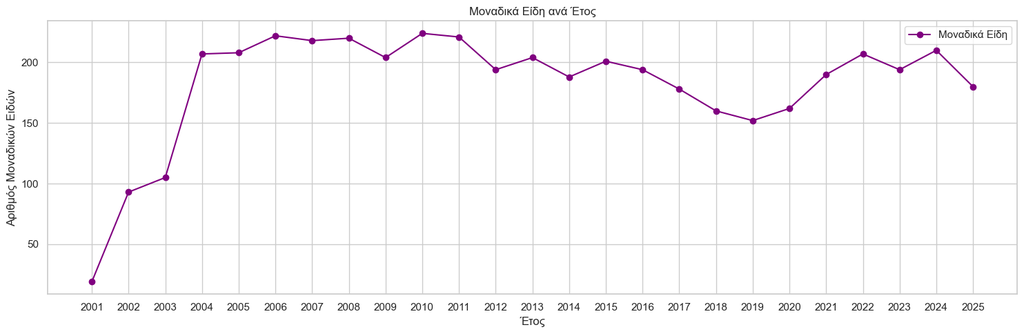

```python
unique_species_per_year = new_df.groupby('year')['species'].nunique().sort_index()
years = unique_species_per_year.index.astype(str)
unique_counts = unique_species_per_year.values

plt.figure(figsize=(15, 5))
plt.plot(years, unique_counts, marker='o', linestyle='-', color='purple')
plt.title('Μοναδικά Είδη ανά Έτος')
plt.xlabel('Έτος')
plt.ylabel('Αριθμός Μοναδικών Ειδών')
plt.legend(['Μοναδικά Είδη'])
plt.tight_layout()

plt.show()
```

#### Β1.iii — Συνδυαστικό Γράφημα Διπλού Άξονα *(5 μονάδες)*

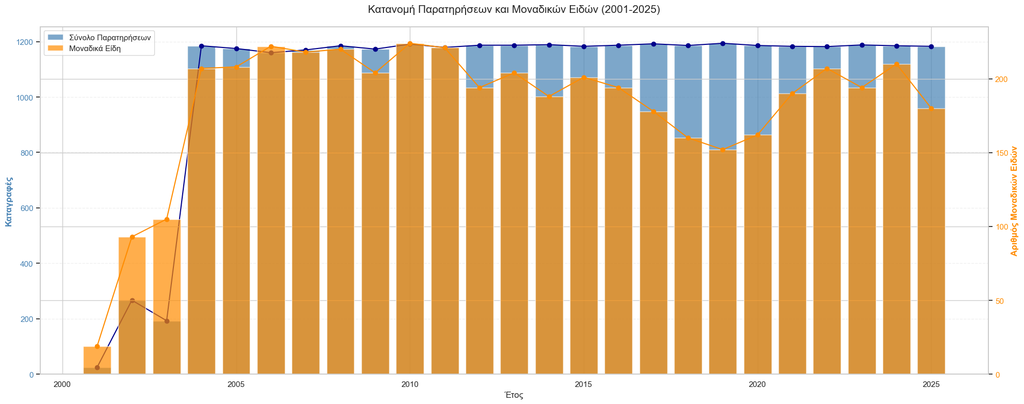

```python
yearly_data = df_raw.groupby('year')

# Δημιουργία του σχήματος και του πρώτου άξονα
fig, ax1 = plt.subplots(figsize=(20, 8))

# Ραβδόγραμμα για τις παρατηρήσεις
ax1.bar(yearly_data.groups.keys(), records_per_year.values, color='steelblue', alpha=0.7, label='Σύνολο Παρατηρήσεων')
ax1.plot(yearly_data.groups.keys(), records_per_year.values, marker='o', linestyle='-', color='darkblue')
ax1.set_xlabel('Έτος', fontsize=12)
ax1.set_ylabel('Καταγραφές', color='steelblue', fontsize=12, fontweight='bold')
ax1.tick_params(axis='y', labelcolor='steelblue')

# Δημιουργία του δεύτερου άξονα
ax2 = ax1.twinx()

# Γραμμή για τα μοναδικά είδη (Δεξιός άξονας)
ax2.bar(yearly_data.groups.keys(), unique_species_per_year.values, color='darkorange', alpha=0.7, label='Μοναδικά Είδη')
ax2.plot(yearly_data.groups.keys(), unique_species_per_year.values, marker='o', linestyle='-', color='darkorange')
ax2.set_ylabel('Αριθμός Μοναδικών Ειδών', color='darkorange', fontsize=12, fontweight='bold')
ax2.tick_params(axis='y', labelcolor='darkorange')


plt.title('Κατανομή Παρατηρήσεων και Μοναδικών Ειδών (2001-2025)', fontsize=15, pad=20)
ax1.grid(axis='y', linestyle='--', alpha=0.3)

# Προσθήκη legend (συνδυασμός και από τους δύο άξονες)
lines1, labels1 = ax1.get_legend_handles_labels()
lines2, labels2 = ax2.get_legend_handles_labels()
ax1.legend(lines1 + lines2, labels1 + labels2, loc='upper left')

plt.tight_layout()
plt.show()
```

**Σχόλιο για ετήσιες τάσεις (Β1.iii):**

- Πότε εμφανίζεται η έντονη αύξηση παρατηρήσεων; Τι την εξηγεί (citizen science, iNaturalist);

  Εμφανίζεται έντονη αύξηση παρατηρήσεων το 2004. Αν και το iNaturalist πρωτοεμφανίστηκε το 2008, επιτρέπει την καταγραφή παλιότερων παρατηρήσεων. Επίσης, το Birdmap data λειτούργησε πρώτη φορά το 2006. Οπότε, η αύξηση οφείλετε αποκλειστικά στο citizen science. Το 2004, λόγω των Ολυμπιακών Αγώνων, υπήρξε μια τεράστια κινητοποίηση στην Ελλάδα για την καταγραφή και την προστασία του περιβάλλοντος. Παράλληλα και ίσως σημαντικότερα, εκείνη την περίοδο η Ελλάδα ολοκλήρωνε και κατέθετε τις επίσημες λίστες για το δίκτυο Natura 2000. Οι επιστημονικές ομάδες που κατέγραψαν πουλιά σε προστατευόμενες περιοχές παρήγαγαν έναν τεράστιο όγκο δεδομένων που έχει ως αφετηρία το 2004.
- Κινούνται παράλληλα οι δύο καμπύλες (παρατηρήσεις & είδη);

  Η καμπύλη των παρατηρήσεων μένει σχετικά σταθερή μετά τη ραγδαία αύξηση ενώ η καμπύλη των ειδών έχει αρκετές αυξομειώσεις. Δεν υπάρχει κάποια συσχέτιση μεταξύ τους, μόνο τα πρώτα έτη όπου υπάρχει έντονη διαφορά στις καταγραφές και κατα συνέπεια και στον αριθμό των μοναδικών ειδών.

### Β2. Εποχιακή Ανάλυση *(20 μονάδες)*

#### Β2.i — Μηνιαία Κατανομή *(5 μονάδες)*

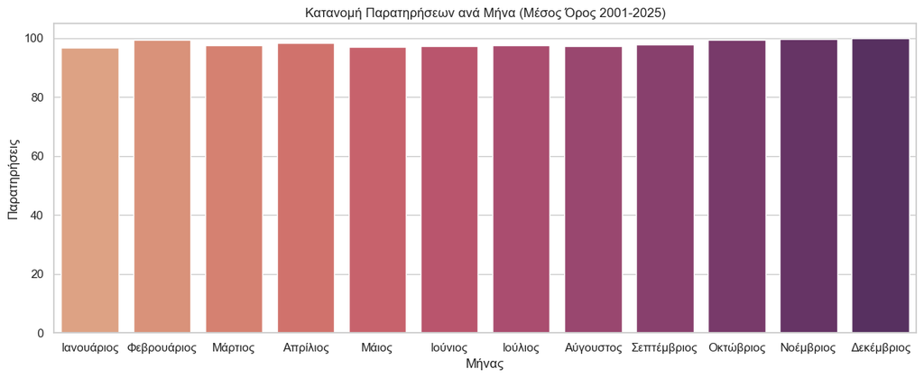

```
Ο μήνας με τις περισσότερες παρατηρήσεις είναι ο/η: Δεκέμβριος
```

```python
monthly_counts = new_df.groupby(['year', 'month']).size().reset_index(name='counts')
monthly_counts = monthly_counts.groupby('month')['counts'].mean()
df = pd.DataFrame(
    {
    'Παρατηρήσεις': monthly_counts.values,
    'Μήνας': ['Ιανουάριος', 'Φεβρουάριος', 'Μάρτιος', 'Απρίλιος', 'Μάιος', 'Ιούνιος', 'Ιούλιος', 'Αύγουστος', 'Σεπτέμβριος', 'Οκτώβριος', 'Νοέμβριος', 'Δεκέμβριος']
    }
)
plt.figure(figsize=(12, 5))
sns.barplot(
    x='Μήνας',
    y='Παρατηρήσεις',
    data=df,
    palette='flare'
)

plt.title("Κατανομή Παρατηρήσεων ανά Μήνα (Μέσος Όρος 2001-2025)")
plt.xlabel('Μήνας')
plt.ylabel('Παρατηρήσεις')
plt.tight_layout()

# Show plot
plt.show()
print(f"\nΟ μήνας με τις περισσότερες παρατηρήσεις είναι ο/η: {df.loc[df['Παρατηρήσεις'].idxmax(), 'Μήνας']}")
```

**Σχόλιο για την αιχμή της κατανομής:**

Ο μήνας που παρουσιάζει την αιχμή κατανομής είναι ο Δεκέμβριος, ωστόσο δεν διαφέρει και πολύ στον αριθμό παρατηρήσεων απο τους υπόλοιπους μήνες. Όπως φάνηκε και στην κατανομή συχνότητας καταγραφής ανα είδος, υπάρχουν είδη με πολλές καταγραφές. Σε συνδυασμό με τα 10 πιο κοινά είδη απο τα οποία είναι σχεδόν όλα επιδημητικά, προκύπτει ότι δεν υπάρχει μεγάλη αλλαγή στον αριθμό των καταγραφών ανά μήνα, αφού δεν υπάρχει μεγάλη μετακίνηση.

#### Β2.ii — Χάρτης Θερμότητας Ελλάδας *(5 μονάδες)*

```python
min_lat=34.0
max_lat=42.0
min_lon=19.0
max_lon=30.0

filtered_df = df_raw[
    (df_raw['decimalLatitude'] > min_lat) &
    (df_raw['decimalLatitude'] < max_lat) &
    (df_raw['decimalLongitude'] > min_lon) &
    (df_raw['decimalLongitude'] < max_lon)
]

# set up the map, centered, zoomed, on given tiles
m = folium.Map(location=[38.0, 24.5],
               zoom_start=6,
               tiles="cartodb positron")

heat_data = filtered_df[['decimalLatitude', 'decimalLongitude']].values.tolist()

HeatMap(
    data=heat_data,
    name='Παρατηρήσεις Πουλιών',
    radius=15,
    blur=20,
    max_zoom=0.5
).add_to(m)

save_to_html = 'birds_greece_heatmap.html'
m.save(save_to_html)
m
```

Make this Notebook Trusted to load map: File -> Trust Notebook

[interactive chart not shown]

**Σχόλιο για τη συγκέντρωση καταγραφών:**

Τη μεγαλύτερη συγκέντρωση την έχουν τα δύο μεγαλύτερα αστικά κέντα Αθήνα/Θεσσαλονίκη. Ακολουθούν τα νησία και οι μεγαλύτεροι υγρότοποι όπως αυτός στο Δέλτα του Νέστου, Δέλτα του Έβρου, στη λίμνη Βιστονίδα, στις λίμνες Βόλβη, Κερκίνη κλπ.

#### Β2.iii — Μεταναστευτικό vs Μόνιμο Είδος *(5 μονάδες)*

```
Μεταναστευτικό είδος: Hirundo rustica (Σταβλοχελίδονο)
Αριθμός εγγραφών μεταναστευτικού είδους: 473
Μόνιμο είδος: Buteo buteo (Γερακίνα)
Αριθμός εγγραφών μόνιμου είδους: 500
```

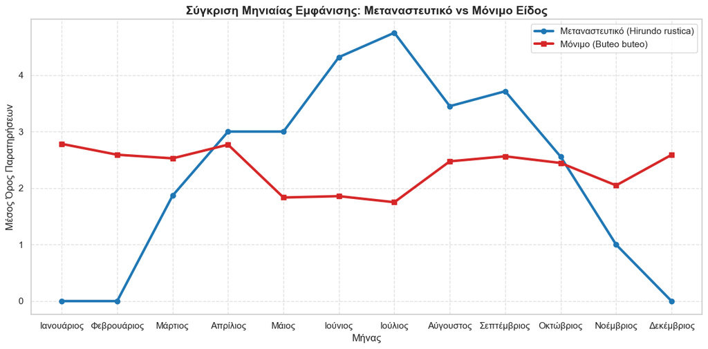

```python
species_migrant  = 'Hirundo rustica'   # επιστημονικό όνομα μεταναστευτικού είδους
species_resident = 'Buteo buteo'   # επιστημονικό όνομα μόνιμου είδους
print(f"Μεταναστευτικό είδος: {species_migrant} ({GREEK_NAMES.get(species_migrant, 'N/A')})")
print(f"Αριθμός εγγραφών μεταναστευτικού είδους: {len(df_raw[df_raw['species'] == species_migrant])}")
print(f"Μόνιμο είδος: {species_resident} ({GREEK_NAMES.get(species_resident, 'N/A')})")
print(f"Αριθμός εγγραφών μόνιμου είδους: {len(df_raw[df_raw['species'] == species_resident])}")

def get_monthly_averages(species_name, df):
    # Φιλτράρουμε για το συγκεκριμένο είδος
    species_df = df[df['species'] == species_name]
    # Ομαδοποίηση ανά έτος/μήνα για να βρούμε τα counts
    counts = species_df.groupby(['year', 'month']).size().reset_index(name='counts')
    # Μέσος όρος ανά μήνα
    return counts.groupby('month')['counts'].mean().reindex(range(1, 13), fill_value=0)

migrant_avg = get_monthly_averages(species_migrant, df_raw)
resident_avg = get_monthly_averages(species_resident, df_raw)

plt.figure(figsize=(12, 6))

# Γραμμή για το μεταναστευτικό είδος
plt.plot(migrant_avg.index, migrant_avg.values, marker='o', linewidth=3,
         label=f'Μεταναστευτικό ({species_migrant})', color='tab:blue')

# Γραμμή για το μόνιμο είδος
plt.plot(resident_avg.index, resident_avg.values, marker='s', linewidth=3,
         label=f'Μόνιμο ({species_resident})', color='tab:red')

plt.xticks(range(1, 13), ['Ιανουάριος', 'Φεβρουάριος', 'Μάρτιος', 'Απρίλιος', 'Μάιος', 'Ιούνιος', 'Ιούλιος', 'Αύγουστος', 'Σεπτέμβριος', 'Οκτώβριος', 'Νοέμβριος', 'Δεκέμβριος'])
plt.title('Σύγκριση Μηνιαίας Εμφάνισης: Μεταναστευτικό vs Μόνιμο Είδος', fontsize=14, fontweight='bold')
plt.xlabel('Μήνας', fontsize=12)
plt.ylabel('Μέσος Όρος Παρατηρήσεων', fontsize=12)
plt.grid(True, linestyle='--', alpha=0.6)
plt.legend()

plt.tight_layout()
plt.show()
```

**Σχόλιο (Β2.iii):**

- Ποια είδη επιλέξατε; Πόσες εγγραφές έχει κάθε ένα στο dataset;

  Έχω επιλέξει ως μεταναστευτικό έιδος το [Σταβλοχελίδονο](https://el.wikipedia.org/wiki/%CE%A3%CF%84%CE%B1%CE%B2%CE%BB%CE%BF%CF%87%CE%B5%CE%BB%CE%AF%CE%B4%CE%BF%CE%BD%CE%BF) με 473 καταγραφές και ως επιδημητικό την [Γερακίνα](https://el.wikipedia.org/wiki/%CE%93%CE%B5%CF%81%CE%B1%CE%BA%CE%AF%CE%BD%CE%B1) με 500 καταγραφές.
- Σε ποιους μήνες εμφανίζεται το μεταναστευτικό είδος; Πότε απουσιάζει;

  Το Σταβλοχελίδονο εμφανίζετα τον Μάρτιο και αποδημεί τον Δεκέμβριο.
- Πώς διαφέρει το μηνιαίο πρότυπο του μόνιμου είδους; Η Γερακίνα απο την άλλη, έχει μια σχετικά σταθερή παρουσία σε κάθε μήνα.

#### Β2.iv — Εποχιακοί Χάρτες & Αξιολόγηση Δεδομένων *(5 μονάδες)*

```python
def make_heatmap(points_df, title):
    """Δημιουργεί folium heatmap από DataFrame με decimalLatitude/decimalLongitude."""
    m = folium.Map(location=[39.0742, 21.8243], zoom_start=6, tiles='CartoDB positron')
    pts = points_df.dropna(subset=['decimalLatitude', 'decimalLongitude'])
    pts = pts[pts['decimalLatitude'].between(34, 42) & pts['decimalLongitude'].between(19, 30)]
    if len(pts) > 0:
        HeatMap(pts[['decimalLatitude', 'decimalLongitude']].values.tolist(),
                radius=14, blur=16, min_opacity=0.4).add_to(m)
    folium.map.Marker(
        [36, 20.5],
        icon=folium.DivIcon(
            html=f'<div style="font-size:14px;font-weight:bold;color:white;'
                 f'background:rgba(0,0,0,0.6);padding:4px 8px;border-radius:4px">{title}</div>'
        )
    ).add_to(m)
    return m

data =[]

data.append(make_heatmap(
    new_df[
        (new_df['species'] == species_resident) &
        (new_df['month'].isin([3, 4, 5]))
    ],
    title=f'{species_resident} - Άνοιξη'
))

data.append(make_heatmap(
    new_df[
        (new_df['species'] == species_resident) &
        (new_df['month'].isin([11, 12, 1]))
    ],
    title=f'{species_resident} - Χειμώνας'
))

data.append(make_heatmap(
    new_df[
        (new_df['species'] == species_migrant) &
        (new_df['month'].isin([3, 4, 5]))
    ],
    title=f'{species_migrant} - Άνοιξη'
))

data.append(make_heatmap(
    new_df[
        (new_df['species'] == species_migrant) &
        (new_df['month'].isin([11, 12, 1]))
    ],
    title=f'{species_migrant} - Χειμώνας'
))

for map in data:
    display(map)
```

Make this Notebook Trusted to load map: File -> Trust Notebook

[interactive chart not shown]

Make this Notebook Trusted to load map: File -> Trust Notebook

[interactive chart not shown]

Make this Notebook Trusted to load map: File -> Trust Notebook

[interactive chart not shown]

Make this Notebook Trusted to load map: File -> Trust Notebook

[interactive chart not shown]

**Σχόλιο (Β2.iv):**

- Αντικατοπτρίζουν οι χάρτες τη γνωστή χωρική κατανομή του κάθε είδους;

  Αναφορικά με το Σταβλοχελίδονο, εμφανίζεται τους ανοιξιάτικους μήνες διάσπαρτα αλλά με επίκεντρο το μεγαλύτερο αστικό κέντρο, ενώ τον χειμώνα υπάρχουν ελάχιστες καταγραφές σε 3 σημεία μόνο. Για τη Γερακίνα, βλέπουμε πως τον χειμώνα κινείται κυρίως σε αστικά κέντρα ενώ την άνοιξη υπάρχει μεγαλύτερη κινητικότητα στα νησιά λόγω της αναζήτησης τροφής. Τα αποτελέσματα αντικατροπτίζουν τη γνωστή χωρική κατανομή του κάθε είδους.
- Παρατηρείτε διαφορές μεταξύ εποχών ή μεταξύ ειδών;

  Μεταξύ εποχών οι διαφορές είναι έντονες όπως φαίνεται στους χάρτες αλλά και όπως προαναφέρθηκε. Μεταξύ των ειδών, η διαφορά είναι τον χειμώνα λόγω της μεταναστευτικής φύσης του Σταβλοχελίδονου.
- Αν κάποιος χάρτης εμφανίζεται αραιός ή κενός, εξηγήστε γιατί — βιολογική συμπεριφορά ή sampling bias (π.χ. εποχιακή διακύμανση παρατηρητών, γεωγραφική συγκέντρωση καταγραφών);

  Ο χάρτης για τον χειμώνα του Σταβλοχελίδονου είναι σχεδόν κενός διότι αποδημεί, ενώ την άνοιξη είναι αραιός μιας και φαίνεται να επιλέγει τα αστικά κέντρα και τους υγροτόπους.

## Μέρος Γ — Χωρική Ανάλυση & Αστικά Κέντρα

### Γ1. Πτηνά στα Αστικά Κέντρα & Νησιωτικές Περιοχές *(10 μονάδες)*

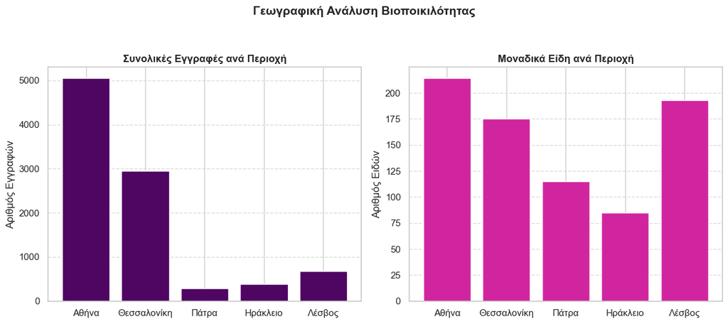

```python
CITIES = {
    'Αθήνα':        (37.98, 23.73),
    'Θεσσαλονίκη':  (40.63, 22.94),
    'Πάτρα':        (38.25, 21.73),
    'Ηράκλειο':     (35.34, 25.13),
    'Λέσβος':       (39.10, 26.55),
}
RADIUS = 0.3  # μοίρες lat/lon (~33 km)
area_bounds = {
    city: (
        lat - RADIUS, lat + RADIUS,
        lon - RADIUS, lon + RADIUS
    )
    for city, (lat, lon) in CITIES.items()
}


# Υπολογισμός των μετρικών για κάθε περιοχή
results = []

for city, (minlat, maxlat, minlon, maxlon) in area_bounds.items():

    # Φιλτράρισμα βάσει των γεωγραφικών συντεταγμένων
    mask = (
        (df_raw['decimalLatitude'] >= minlat) & (df_raw['decimalLatitude'] <= maxlat) &
        (df_raw['decimalLongitude'] >= minlon) & (df_raw['decimalLongitude'] <= maxlon)
    )
    filtered_df = df_raw[mask]

    # Υπολογισμός (α) Συνολικές εγγραφές και (β) Μοναδικά είδη
    total_records = len(filtered_df)
    unique_species = filtered_df['species'].nunique()

    results.append({
        "Περιοχή": city,
        "Συνολικές Εγγραφές": total_records,
        "Μοναδικά Είδη": unique_species
    })

# Μετατροπή των αποτελεσμάτων σε DataFrame για εύκολη διαχείριση/σχεδίαση
results_df = pd.DataFrame(results)

# Απεικόνιση σε διπλό ραβδόγραμμα (δίπλα-δίπλα)
fig, axes = plt.subplots(1, 2, figsize=(12, 5))

# Χρώματα για να ξεχωρίζουν τα γραφήματα
color_records = "#4f0562"
color_species = "#D125A0"

# Panel 1: Συνολικές Εγγραφές
axes[0].bar(results_df["Περιοχή"], results_df["Συνολικές Εγγραφές"], color=color_records)
axes[0].set_title("Συνολικές Εγγραφές ανά Περιοχή", fontweight='bold')
axes[0].set_ylabel("Αριθμός Εγγραφών")
axes[0].grid(axis='y', linestyle='--', alpha=0.7)

# Panel 2: Μοναδικά Είδη
axes[1].bar(results_df["Περιοχή"], results_df["Μοναδικά Είδη"], color=color_species)
axes[1].set_title("Μοναδικά Είδη ανά Περιοχή", fontweight='bold')
axes[1].set_ylabel("Αριθμός Ειδών")
axes[1].grid(axis='y', linestyle='--', alpha=0.7)

plt.suptitle("Γεωγραφική Ανάλυση Βιοποικιλότητας", fontsize=14, fontweight='bold', y=1.05)
plt.tight_layout()
plt.show()
```

**Σχόλιο (Γ1):**

- Ποια περιοχή έχει τις περισσότερες παρατηρήσεις; Ποια τη μεγαλύτερη ποικιλότητα ειδών;

  Η Αθήνα έχει τις περισσότερες καταγραφές αλλά και τη μεγαλύτερη ποικιλότητα ειδών.
- Συμπίπτουν οι δύο κατατάξεις; Διατυπώστε υπόθεση για τα αίτια.

### Γ2. Κυρίαρχα Είδη ανά Περιοχή *(12 μονάδες)*

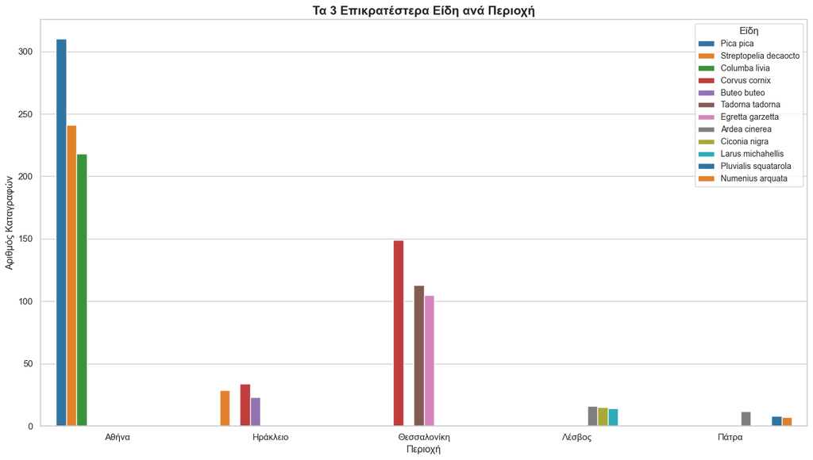

```python
def assign_region(row):
    for city, (min_lat, max_lat, min_lon, max_lon) in area_bounds.items():
        if min_lat <= row['decimalLatitude'] <= max_lat and min_lon <= row['decimalLongitude'] <= max_lon:
            return city
    return None

df_raw['region'] = df_raw.apply(assign_region, axis=1)
df_filtered = df_raw.dropna(subset=['region'])

top3_species = (
    df_filtered.groupby(['region', 'species'])
    .size()
    .reset_index(name='count')
    .sort_values(['region', 'count'], ascending=[True, False])
    .groupby('region')
    .head(3)
)

plt.figure(figsize=(14, 8))

ax = sns.barplot(
    data=top3_species,
    x='region',
    y='count',
    hue='species',
    palette='tab10'
)

plt.title('Τα 3 Επικρατέστερα Είδη ανά Περιοχή', fontsize=15, fontweight='bold')
plt.xlabel('Περιοχή', fontsize=12)
plt.ylabel('Αριθμός Καταγραφών', fontsize=12)

plt.legend(title='Είδη', loc='upper right', fontsize='small')

plt.tight_layout()
plt.show()
```

**Σχόλιο (Γ2):**

- Είναι τα κυρίαρχα είδη κοινά σε όλες τις περιοχές, ή διαφέρουν;

  Tα κυρίαρχα είδη διαφέρουν απο περιοχή σε περιοχή.
- Τι εξηγεί τις ομοιότητες ή διαφορές (αστικό περιβάλλον, υγρότοποι, νησιωτικά είδη);

### Γ3. Εποχιακό Προφίλ ανά Περιοχή *(13 μονάδες)*

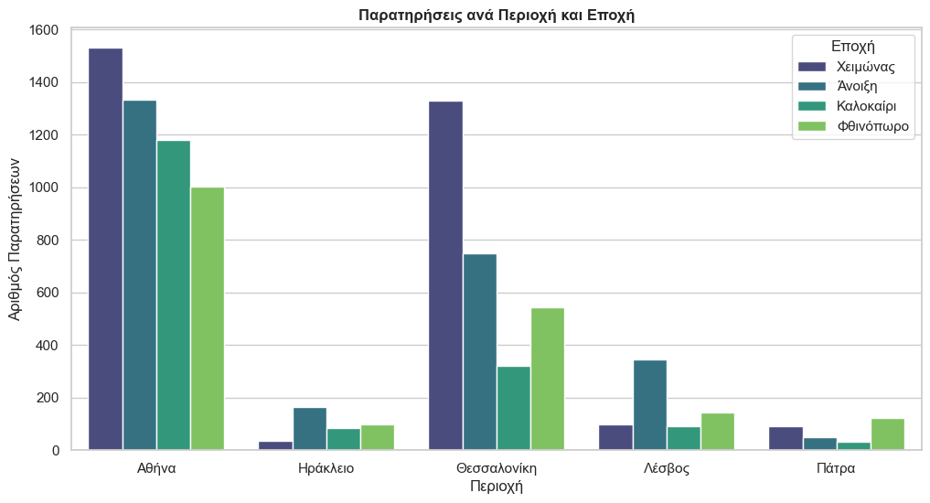

```python
def get_season(month):
    if month in [3, 4, 5]: return 'Άνοιξη'
    if month in [6, 7, 8]: return 'Καλοκαίρι'
    if month in [9, 10, 11]: return 'Φθινόπωρο'
    return 'Χειμώνας'

# Αντιστοίχιση των lat/lon από το df_raw στις περιοχές του area_bounds
def find_region(row):
    for city, (min_lat, max_lat, min_lon, max_lon) in area_bounds.items():
        if min_lat <= row['decimalLatitude'] <= max_lat and min_lon <= row['decimalLongitude'] <= max_lon:
            return city
    return None

df_raw['region'] = df_raw.apply(find_region, axis=1)
df_raw['season'] = df_raw['month'].apply(get_season)

df_filtered = df_raw.dropna(subset=['region'])

seasonal_data = df_filtered.groupby(['region', 'season']).size().reset_index(name='observations')

plt.figure(figsize=(12, 6))
sns.barplot(
    data=seasonal_data,
    x='region',
    y='observations',
    hue='season',
    hue_order=['Χειμώνας', 'Άνοιξη', 'Καλοκαίρι', 'Φθινόπωρο'],
    palette='viridis'
)

plt.title('Παρατηρήσεις ανά Περιοχή και Εποχή', fontweight='bold')
plt.ylabel('Αριθμός Παρατηρήσεων')
plt.xlabel('Περιοχή')
plt.legend(title='Εποχή')
plt.show()
```

**Σχόλιο (Γ3):**

- Ποια περιοχή–εποχή παρουσιάζει τη μεγαλύτερη δραστηριότητα;

  Η Αθήνα τον χειμώνα φαίνεται να έχει τη μεγαλύτερη δραστηριότητα. Αυτό ίσως να οφείλετε στους ζεστούς της χειμώνες που επιτρέπουν στα πτηνά να βρουν τροφή και να δραστηριοποιούνται αλλά και σε κάποια είδη που επιλέγουν τα αστικά κέντρα τον χειμώνα.
- Παρατηρείτε διαφορές μεταξύ αστικών κέντρων και νησιωτικής περιοχής (Λέσβος);

## Συμπεράσματα

- **Κυρίαρχα Είδη:** Στα ατικά κέντρα παρατηρείται υψηλή κυριαρχία λίγων, συγκεκριμένων ειδών. Αυτά τα είδη είναι προσαρμοσμένα στο αστικό περιβάλλον και καταλαμβάνουν το μεγαλύτερο ποσοστό των καταγραφών. Απο την άλλη, στις νησιωτικές περιοχές κυριαρχούν είδη που εξαρτώνται από συγκεκριμένους βιοτόπους.
- **Εποχιακότητα:** Η Αθήνα παρουσιάζει τη μεγαλύτερη δραστηριότητα τον χειμώνα λόγω της θερμοκρασίας της.
- **Γεωγραφία & Αστικά Κέντρα:** Παρά τον μεγάλο όγκο δεδομένων στην Θεσσαλονίκη, η ποικιλότητα είναι χαμηλότερη σε σχέση με τη Λέσβο, καθώς η πόλη είναι γεωγραφικά πιο ομογενοποιημένη (τσιμέντο), οπότε φιλοξένει συγκεκριμένα είδη.
- **Ποιότητα Δεδομένων / Sampling Bias:** Ο αριθμός των καταγραφών δεν αντικατροπτίζει την πραγματική δραστηριότητα των πτηνών, είναι ενα μικρό δείγμα των 100 καταγραφών ανά μήνα για 25 χρόνια. Οι εγγραφές είναι απλά σημεία που υπήρξαν άνθρωποι για να καταγράψουν την ύπαρξη πτηνών και να τη δημοσιοποίησαν. Παράδειγμα είναι η Αθήνα η οποία έχει μία καλύτερη εκπροσώπιση λόγω πληθυσμού, ενώ οι επαρχιακές πόλεις δεν έχουν πληθώρα δεδομένων.

### Αναφορά Πηγής Δεδομένων

GBIF.org — Global Biodiversity Information Facility  
Taxon: *Aves* (taxonKey: 212) | Χώρα: Ελλάδα | Άδεια: CC0 1.0 / CC-BY 4.0  
*Έχει γίνει χρήση των αδειών **[CC BY 4.0](https://creativecommons.org/licenses/by/4.0/legalcode)**, **[CC BY-NC 4.0](https://creativecommons.org/licenses/by-nc/4.0/legalcode)** αλλά και της **[CC0 1.0](https://creativecommons.org/publicdomain/zero/1.0/legalcode)**.*